# Estimate tree height and crown dimensions

## Other trees

### Fits and compares height-diameter models (BIOMASS)

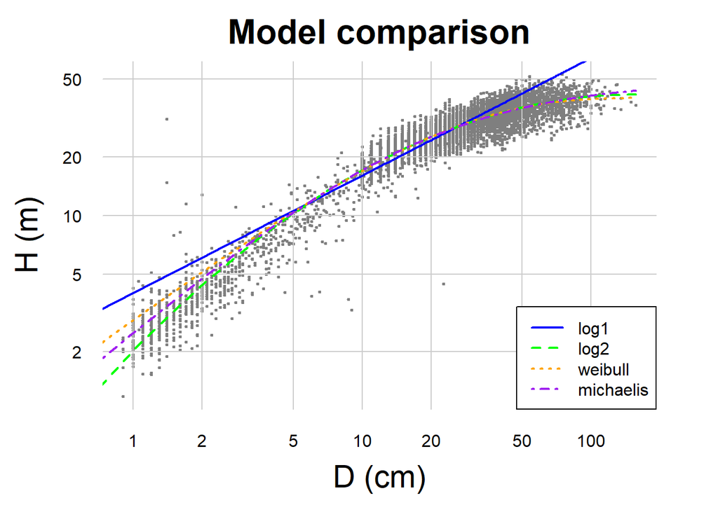

```r
ModelsresultGuiana <- modelHD( # fits and compares (optional) height-diameter models
  D = data$DBH,
  H = data$TreeHeight,
  useWeight = F
)
```

```r
knitr::kable(ModelsresultGuiana)
```

| method | color | RSE | RSElog | Average_bias |
| --- | --- | --- | --- | --- |
| log1 | blue | 4.661391 | 0.1753944 | 0.0207104 |
| log2 | green | 2.792222 | 0.1214638 | 0.0008841 |
| weibull | orange | 2.797694 | NA | 0.0007105 |
| michaelis | purple | 2.796711 | NA | 0.0006911 |

```r
# the lowest RSE: log2 (RSE= 2.792), michaelis :    2.796711

HDmodelGuiana <- modelHD(
  D = data$DBH,
  H = data$TreeHeight,
  method = "michaelis", # Compute the H-D model with the lowest RSE.
  useWeight = F # T = larger trees have a stronger influence during the construction of the model
)
HDmodelGuiana$coefficients
```

```
  Estimate Std. Error  t value Pr(>|t|)
A 48.87652  0.1526790 320.1261        0
B 18.59470  0.1285109 144.6936        0
```

```r
# log2 : exp(0.6988852 + 1.1989242*log(DBH) + -0.1187707*log(DBH)^2)
# michaelis : (48.87652 * DBH)/(18.59470 + DBH) *exp(error)

EstimA <- Adults %>%
  filter(is.na(TreeHeight)) %>% # 24 trees
  mutate(TreeHeight = ifelse(Multistem==T, retrieveH(D= Diameter, model = HDmodelGuiana)$H, # Diameter -> DBH
                             retrieveH(D= DBHcor, model = HDmodelGuiana)$H)) %>%
  mutate(HeightHow = "Local allometry")

Adults <- Adults %>%
  filter(!is.na(TreeHeight)) %>%
  bind_rows(EstimA) %>%
  mutate(CrownHeight = TreeHeight*0.3)
```

#### For DBH < 10 cm

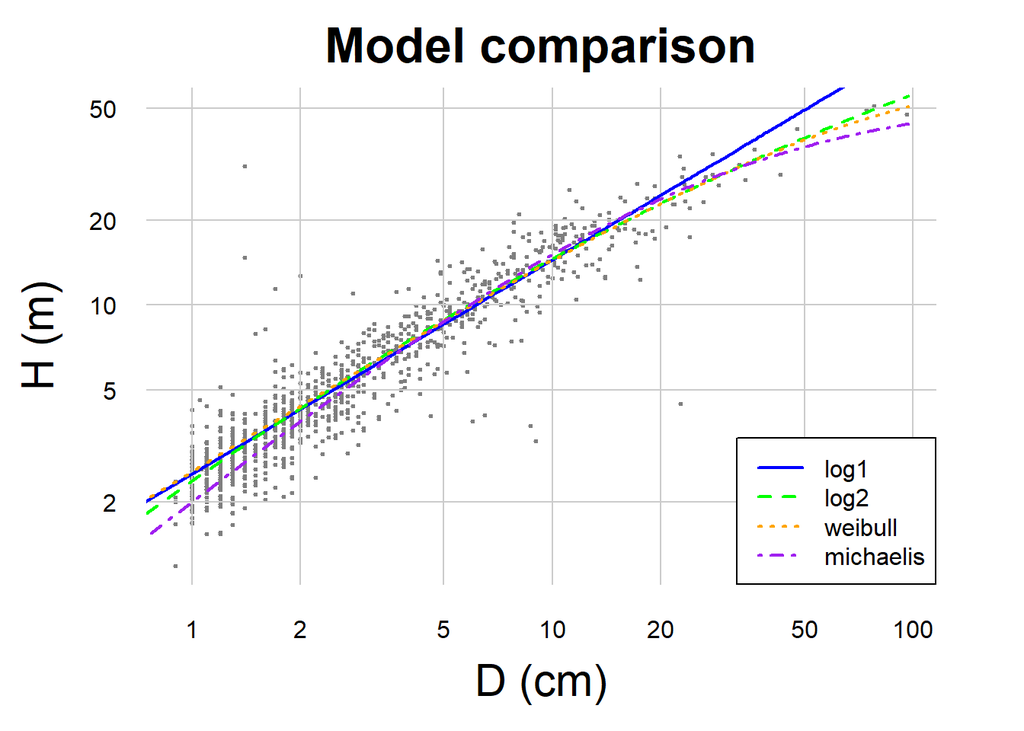

```r
ModelsresultGuiana <- modelHD( # fits and compares (optional) height-diameter models
  D = FTH$DBH,
  H = FTH$TreeHeight,
  useWeight = F
)
```

```r
knitr::kable(ModelsresultGuiana)
```

| method | color | RSE | RSElog | Average_bias |
| --- | --- | --- | --- | --- |
| log1 | blue | 2.734142 | 0.2600670 | 0.0153104 |
| log2 | green | 2.237065 | 0.2571813 | 0.0008791 |
| weibull | orange | 2.236801 | NA | 0.0036339 |
| michaelis | purple | 2.307562 | NA | -0.0302759 |

```r
# the lowest RSE: log2 (RSE= 2.792), michaelis :    2.796711

HDmodelGuiana <- modelHD(
  D = FTH$DBH,
  H = FTH$TreeHeight,
  method = "michaelis", # Compute the H-D model with the lowest RSE.
  useWeight = F # T = larger trees have a stronger influence during the construction of the model
)
HDmodelGuiana$coefficients
```

```
  Estimate Std. Error  t value      Pr(>|t|)
A 56.50178   1.760579 32.09272 1.980683e-152
B 27.27932   1.227774 22.21851  5.768145e-88
```

```r
# log2 : exp(0.6988852 + 1.1989242*log(DBH) + -0.1187707*log(DBH)^2)
# michaelis : (48.87652 * DBH)/(18.59470 + DBH) *exp(error)

EstimU <- Understory %>% # 28 711
  filter(is.na(TreeHeight)) %>% # 28 045 trees
  mutate(TreeHeight = ifelse(Multistem==T, retrieveH(D= DBH, model = HDmodelGuiana)$H,
                             retrieveH(D= DBHcor, model = HDmodelGuiana)$H)) %>%
  mutate(HeightHow = "Local allometry")

Understory <- Understory %>%
  filter(!is.na(TreeHeight)) %>%
  bind_rows(EstimU) %>%
  mutate(CrownHeight = TreeHeight*0.3)
```

```r
Understory %>% filter(is.na(TreeHeight))
```

## Plot Tree and crown heights estimation

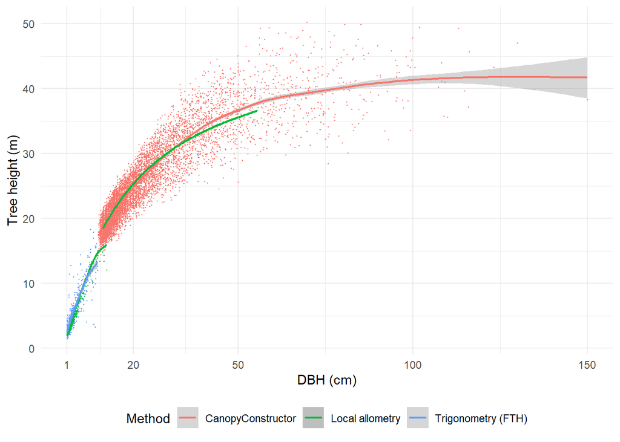

```r
Adults %>%
  # bind_rows(Understory) %>%
  ggplot() +
  aes(x = DBHcor, y = TreeHeight, colour= HeightHow) +
  geom_point(shape = "circle", size = 0.2) +
  geom_smooth(span = 0.75, linewidth = 0.8) +
  geom_point(data= Understory, shape = "circle", size = 0.2) +
  geom_smooth(data= Understory, span = 0.75, linewidth = 0.8) +
  scale_x_continuous(breaks = c(1, 20, 50, 100, 150)) +
  theme_minimal() +
  # scale_color_manual(values = c("Local allometry" = "#00AFBB",
  #                               "CanopyConstructor"= "#E7B800")) +
  labs(x ="DBH (cm)", y = "Tree height (m)", colour = "Method") +
  theme(legend.position="bottom"
        # axis.title= element_text(size=16), axis.text= element_text(size=16),
        # legend.title= element_text(size=16), legend.text= element_text(size=16)
  )
```

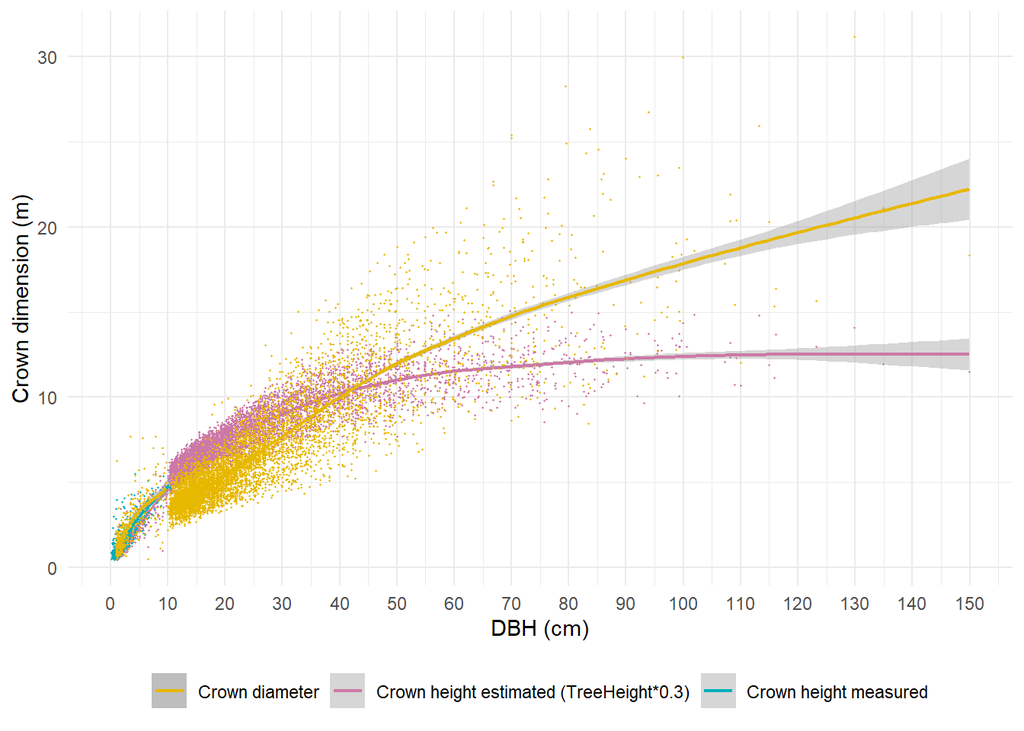

```r
Adults %>%
  ggplot() +
  aes(x = DBHcor, y = CrownHeight) +
  geom_point(aes(col = "Crown height estimated (TreeHeight*0.3)"), size = 0.2) +
  geom_smooth(span = 0.75, linewidth = 0.8, aes(color = "Crown height estimated (TreeHeight*0.3)")) +
  geom_point(data= Understory, size = 0.2, aes(color = "Crown height estimated (TreeHeight*0.3)")) +
  geom_point(data= Understory, size = 0.2, aes(TreeHeight - CrownBase, col = "Crown height measured")) +
  geom_smooth(data= Understory, span = 0.75, linewidth = 0.8, aes(TreeHeight - CrownBase, col = "Crown height measured")) +

  geom_point(data= Understory, size = 0.2, aes(y = CrownRadius*2, color = "Crown diameter")) +
  geom_smooth(data= Understory, span = 0.75, linewidth = 0.8, aes(y = CrownRadius*2, color = "Crown diameter")) + # using method = 'gam' and formula 'y ~ s(x, bs = "cs")'


  geom_point(size = 0.2, aes(y = CrownRadius*2, color = "Crown diameter")) +
  geom_smooth(span = 0.75, linewidth = 0.8, aes(y = CrownRadius*2, color = "Crown diameter")) + # using method = 'gam' and formula 'y ~ s(x, bs = "cs")'

  theme_minimal() +
  scale_color_manual(values = c("Crown height estimated (TreeHeight*0.3)" = "#CC79A7",
                                "Crown height measured" = "#00AFBB",
                                "Crown diameter"= "#E7B800")) +
  labs(x ="DBH (cm)", y = "Crown dimension (m)") +
  scale_x_continuous(limits = c(0, 150), breaks = seq(0, 150, by=10)) +
  theme(legend.position="bottom",
        # axis.title= element_text(size=16), axis.text= element_text(size=16),
        # legend.title= element_text(size=16), legend.text= element_text(size=16)
        legend.title= element_blank())
```

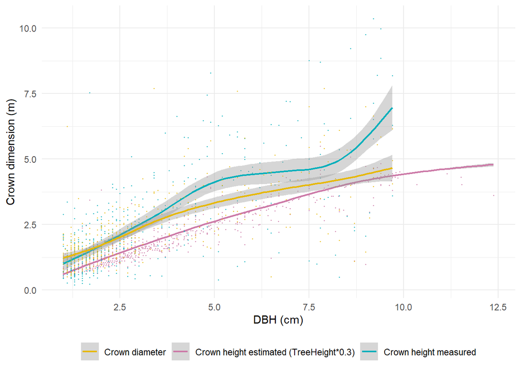

```r
# ggsave("CrownDimensions-FTH_Claudiasdata.png", path= "D:/Mes Donnees/PhD/Figures/inventory", width = 20, height = 15, units = "cm", dpi=800, bg="white")

Understory %>%
  ggplot() +
  # Estimated height
  aes(x = DBHcor, y = CrownHeight) +
  geom_point(aes(col = "Crown height estimated (TreeHeight*0.3)"), size = 0.2) +
  geom_smooth(span = 0.75, linewidth = 0.8, aes(col = "Crown height estimated (TreeHeight*0.3)")) +
  # Measured height
  geom_point(aes(y = TreeHeight - CrownBase, col = "Crown height measured"), size = 0.2) +
  geom_smooth(span = 0.75, linewidth = 0.8, aes(y = TreeHeight - CrownBase, col = "Crown height measured")) +
  # Measured diameter
  geom_point(size = 0.2, aes(y = CrownRadius*2, col = "Crown diameter")) +
  geom_smooth(span = 0.75, linewidth = 0.8, aes(y = CrownRadius*2, col = "Crown diameter")) +

  theme_minimal() +
  scale_color_manual(values = c("Crown height estimated (TreeHeight*0.3)" = "#CC79A7",
                                "Crown height measured" = "#00AFBB",
                                "Crown diameter"= "#E7B800")) +
  labs(x ="DBH (cm)", y = "Crown dimension (m)") +
  # scale_x_continuous(limits = c(0, 150), breaks = seq(0, 150, by=10)) +
  theme(legend.position="bottom",
        # axis.title= element_text(size=16), axis.text= element_text(size=16),
        # legend.title= element_text(size=16), legend.text= element_text(size=16)
        legend.title= element_blank())
```

## Crown radius allometry

### Plot data - relation CrownRadius-DBH

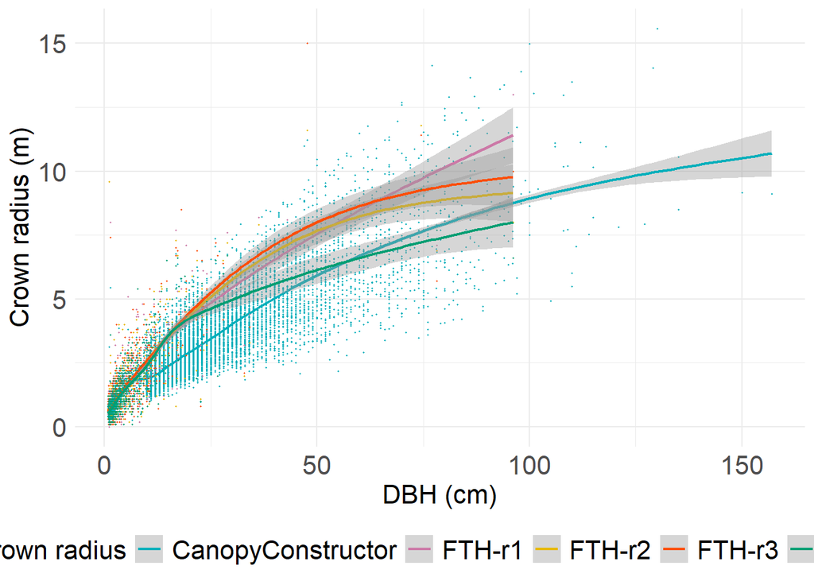

```r
data %>%
  ggplot() +
  aes(x = DBH) +
  geom_point(aes(y = CrownRadius, color = "CanopyConstructor"), shape = "circle", size = 0.2) +
  geom_smooth(aes(y = CrownRadius, color = "CanopyConstructor"), span = 0.75, linewidth = 0.8) +

  geom_point(aes(y = r1, color = "FTH-r1"), shape = "circle", size = 0.2) +
  geom_smooth(aes(y = r1, color = "FTH-r1"), span = 0.75, linewidth = 0.8) +

  geom_point(aes(y = r2, color = "FTH-r2"), shape = "circle", size = 0.2) +
  geom_smooth(aes(y = r2, color = "FTH-r2"), span = 0.75, linewidth = 0.8) +

  geom_point(aes(y = r3, color = "FTH-r3"), shape = "circle", size = 0.2) +
  geom_smooth(aes(y = r3, color = "FTH-r3"), span = 0.75, linewidth = 0.8) +

  geom_point(aes(y = r4, color = "FTH-r4"), shape = "circle", size = 0.2) +
  geom_smooth(aes(y = r4, color = "FTH-r4"), span = 0.75, linewidth = 0.8) +

  scale_color_manual(name = "Crown radius",
                     values = c("CanopyConstructor" = "#00AFBB",
                                "FTH-r1"= "#CC79A7",
                                "FTH-r2"= "#E7B800",
                                "FTH-r3" = "#FC4E07",
                                "FTH-r4" = "#009E73")) +

  theme_minimal() +
  labs(x ="DBH (cm)", y = "Crown radius (m)") +
  theme(axis.title= element_text(size=16), axis.text= element_text(size=16),
        legend.title= element_text(size=16), legend.text= element_text(size=16),
        legend.position="bottom")
```

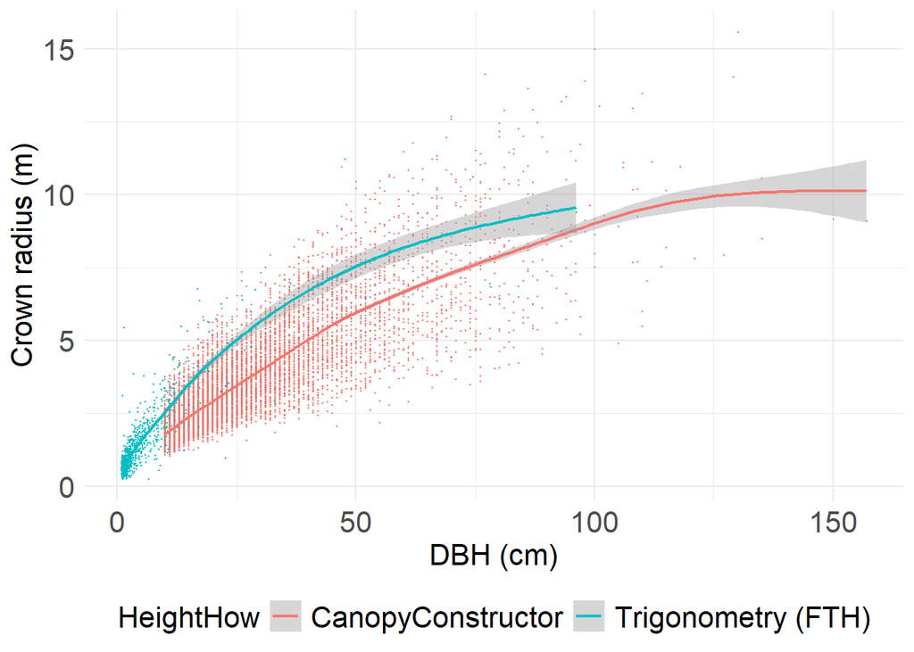

```r
# ggsave("DBH_CrownRadius_CCandFTH.png", path = "D:/Mes Donnees/PhD/Figures/inventory",
#        width = 25, height = 20, units = "cm", dpi=800, bg="white")

# Average FTH
data %>%
  ggplot() +
  aes(x = DBH, col=HeightHow) +
  geom_point(aes(y = CrownRadius), shape = "circle", size = 0.2) +
  geom_smooth(aes(y = CrownRadius), span = 0.75, linewidth = 0.8) +
  theme_minimal() +
  labs(x ="DBH (cm)", y = "Crown radius (m)") +
  theme(axis.title= element_text(size=16), axis.text= element_text(size=16),
        legend.title= element_text(size=16), legend.text= element_text(size=16),
        legend.position="bottom")
```

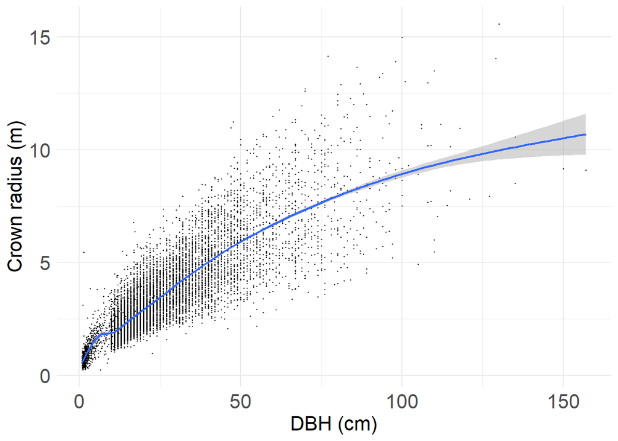

```r
# together
data %>%
  ggplot() +
  aes(x = DBH) +
  geom_point(aes(y = CrownRadius), shape = "circle", size = 0.2) +
  geom_smooth(aes(y = CrownRadius), span = 0.75, linewidth = 0.8) +
  theme_minimal() +
  labs(x ="DBH (cm)", y = "Crown radius (m)") +
  theme(axis.title= element_text(size=16), axis.text= element_text(size=16),
        legend.title= element_text(size=16), legend.text= element_text(size=16),
        legend.position="bottom")
```

### Plot data - relation CrownRadius-TreeHeight

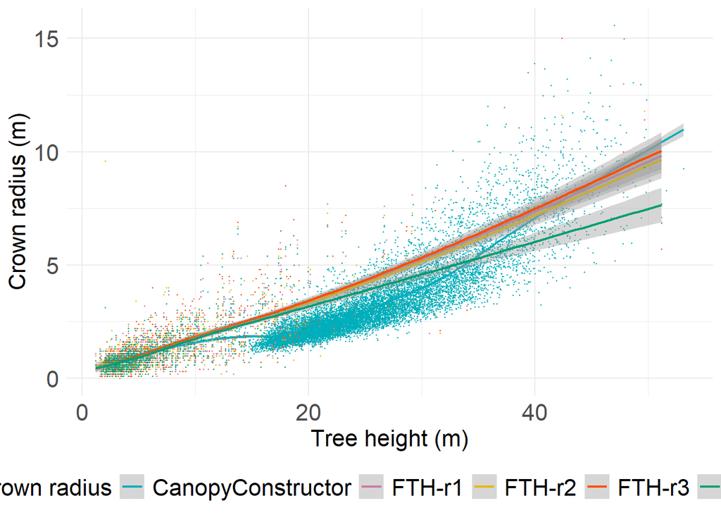

```r
data %>%
  ggplot() +
  aes(x = TreeHeight) +
  geom_point(aes(y = CrownRadius, color = "CanopyConstructor"), shape = "circle", size = 0.2) +
  geom_smooth(aes(y = CrownRadius, color = "CanopyConstructor"), span = 0.75, linewidth = 0.8) +

  geom_point(aes(y = r1, color = "FTH-r1"), shape = "circle", size = 0.2) +
  geom_smooth(aes(y = r1, color = "FTH-r1"), span = 0.75, linewidth = 0.8) +

  geom_point(aes(y = r2, color = "FTH-r2"), shape = "circle", size = 0.2) +
  geom_smooth(aes(y = r2, color = "FTH-r2"), span = 0.75, linewidth = 0.8) +

  geom_point(aes(y = r3, color = "FTH-r3"), shape = "circle", size = 0.2) +
  geom_smooth(aes(y = r3, color = "FTH-r3"), span = 0.75, linewidth = 0.8) +

  geom_point(aes(y = r4, color = "FTH-r4"), shape = "circle", size = 0.2) +
  geom_smooth(aes(y = r4, color = "FTH-r4"), span = 0.75, linewidth = 0.8) +

  scale_color_manual(name = "Crown radius",
                     values = c("CanopyConstructor" = "#00AFBB",
                                "FTH-r1"= "#CC79A7",
                                "FTH-r2"= "#E7B800",
                                "FTH-r3" = "#FC4E07",
                                "FTH-r4" = "#009E73")) +

  theme_minimal() +
  labs(x ="Tree height (m)", y = "Crown radius (m)") +
  theme(axis.title= element_text(size=16), axis.text= element_text(size=16),
        legend.title= element_text(size=16), legend.text= element_text(size=16),
        legend.position="bottom")
```

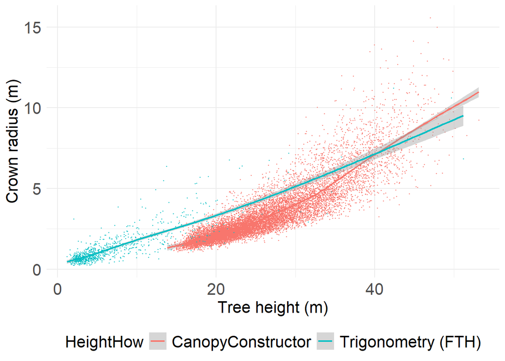

```r
# ggsave("TreeHeight_CrownRadius_CCandFTH.png", path = "D:/Mes Donnees/PhD/Figures/inventory",
#        width = 25, height = 20, units = "cm", dpi=800, bg="white")

# Average FTH
data %>%
  ggplot() +
  aes(x = TreeHeight, col=HeightHow) +
  geom_point(aes(y = CrownRadius), shape = "circle", size = 0.2) +
  geom_smooth(aes(y = CrownRadius), span = 0.75, linewidth = 0.8) +
  theme_minimal() +
  labs(x ="Tree height (m)", y = "Crown radius (m)") +
  theme(axis.title= element_text(size=16), axis.text= element_text(size=16),
        legend.title= element_text(size=16), legend.text= element_text(size=16),
        legend.position="bottom")
```

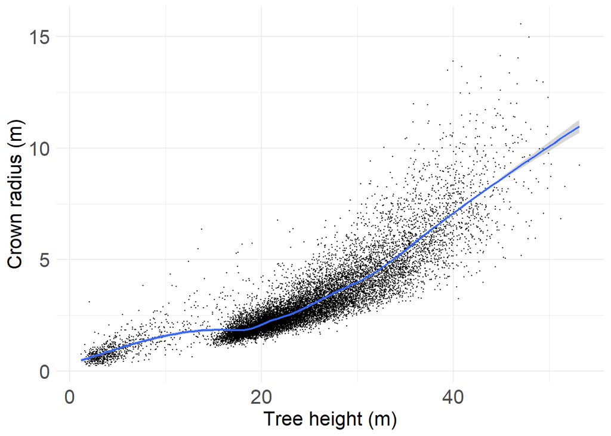

```r
# together
data %>%
  ggplot() +
  aes(x = TreeHeight) +
  geom_point(aes(y = CrownRadius), shape = "circle", size = 0.2) +
  geom_smooth(aes(y = CrownRadius), span = 0.75, linewidth = 0.8) +
  theme_minimal() +
  labs(x ="Tree height (m)", y = "Crown radius (m)") +
  theme(axis.title= element_text(size=16), axis.text= element_text(size=16),
        legend.title= element_text(size=16), legend.text= element_text(size=16),
        legend.position="bottom")
```

### Plot crown base height

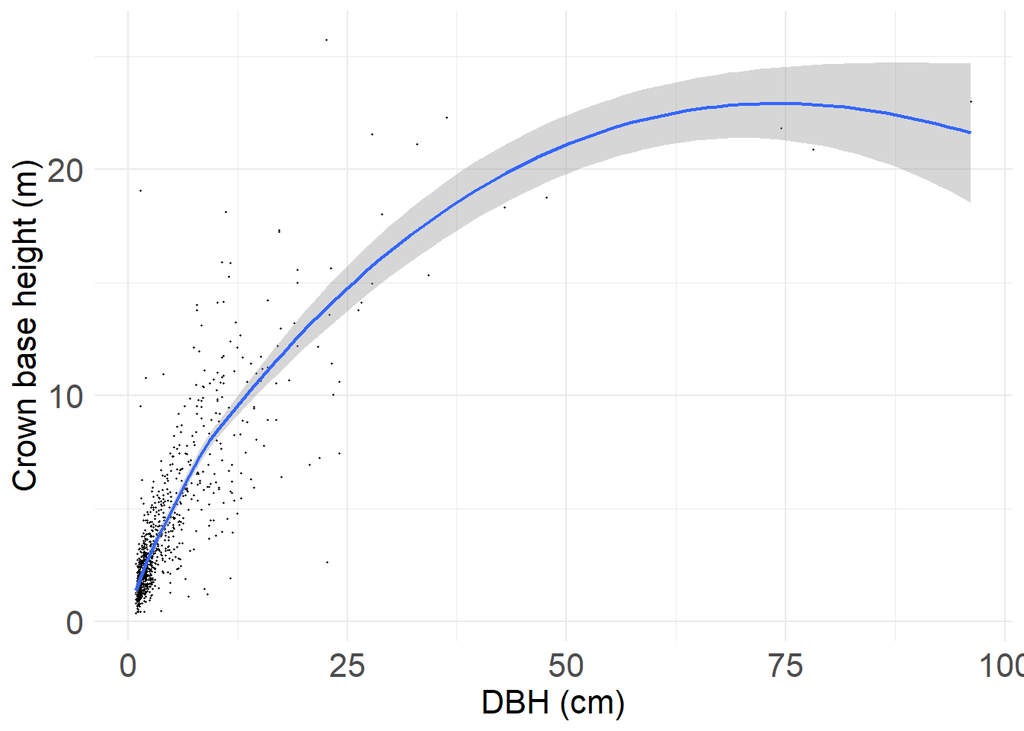

```r
FTH %>%
  ggplot() +
  aes(x = DBH, y = CrownBase) +
  geom_point(shape = "circle", size = 0.2) + # , colour = "#440154"
  geom_smooth(span = 0.75, linewidth = 0.8) +
  theme_minimal() +
  labs(x ="DBH (cm)", y = "Crown base height (m)") +
  theme(axis.title= element_text(size=16), axis.text= element_text(size=16),
        legend.title= element_text(size=16), legend.text= element_text(size=16))
```

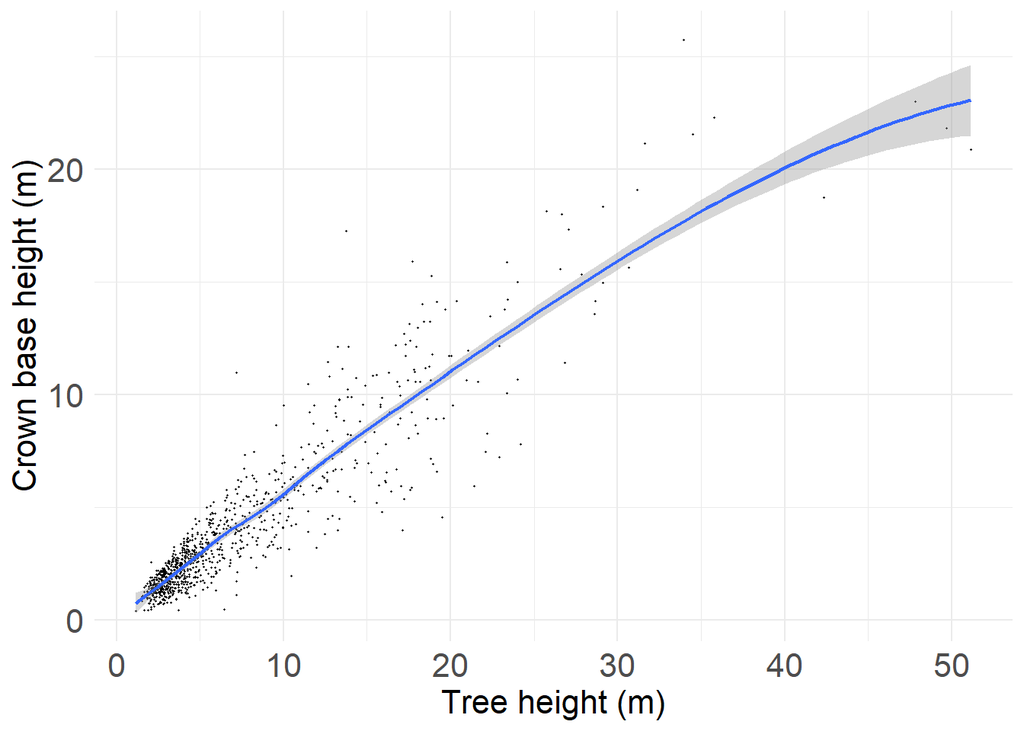

```r
# ggsave("DBH_CrownBase_CanopyConstructor.png", path = "D:/Mes Donnees/PhD/Figures/inventory",
#        width = 20, height = 20, units = "cm", dpi=800, bg="white")

FTH %>%
  ggplot() +
  aes(x = TreeHeight, y = CrownBase) +
  geom_point(shape = "circle", size = 0.2) + # , colour = "#440154"
  geom_smooth(span = 0.75, linewidth = 0.8) +
  theme_minimal() +
  labs(x ="Tree height (m)", y = "Crown base height (m)") +
  theme(axis.title= element_text(size=16), axis.text= element_text(size=16),
        legend.title= element_text(size=16), legend.text= element_text(size=16))
```

```r
# ggsave("Height_CrownBase_CanopyConstructor.png", path = "D:/Mes Donnees/PhD/Figures/inventory",
# width = 20, height = 20, units = "cm", dpi=800, bg="white")

mean(FTH$CrownBase/FTH$TreeHeight, na.rm = T) # 0.58
```

```
[1] 0.5805458
```

```r
# 2/3 = 0.7
# 3/5 = 0.6
```

### Estimate CrownRadius

Pour estimer le rayon de la couronne des arbres absents des données de Claudia, je dois utiliser l’allométrie de CanopyConstructor dont je ne connais pas la valeur des paramètres. Donc je dois les estimer à partir des données de Claudia pour les arbres >10 cm.

Pour les arbres >=10 cm, on fitte l’allométrie sur les données de Claudia et FTH  
Pour les arbres <10 cm, on fitte l’allométrie que sur les données FTH (vaut mieux surestimer la couronne pour éviter l’auto-ombrage)

### For DBH >= 10 cm

```r
# La relation allométrique de CanopyConstructor : exp(alpha + epsilon) * DBH^beta

# Modèle linéaire pour estimation initiale
lm_fit <- lm(log(data$CrownRadius) ~ log(data$DBH), data = data)

# Estimations initiales
alpha_init <- coef(lm_fit)[1] # -0.815
beta_init <- coef(lm_fit)[2] # 0.629

# Ajustement avec nls (Nonlinear Least Squares)
nls_fit <- nls(CrownRadius ~ exp(alpha) * (DBH^beta),
               data = data,
               start = list(alpha = alpha_init, beta = beta_init))

# Récupérer les paramètres estimés
coef <- coef(nls_fit)

# Estimation
EstimA <- Adults %>%
  filter(is.na(CrownRadius)) %>% # 24 trees
  mutate(CrownRadius = ifelse(Multistem==T, exp(coef["alpha"] + coef["beta"] * log(Diameter)), # Diameter -> DBH
                              exp(coef["alpha"] + coef["beta"] * log(DBHcor))))

Adults <- Adults %>%
  filter(!is.na(CrownRadius)) %>%
  bind_rows(EstimA)

CC <- CC %>%
  mutate(CrownRadius_est = exp(coef["alpha"]) * (DBH^coef["beta"]))
```

### For DBH < 10 cm

```r
# La relation allométrique de CanopyConstructor : exp(alpha + epsilon) * DBH^beta

# Modèle linéaire pour estimation initiale
lm_fit <- lm(log(FTH$CrownRadius) ~ log(FTH$DBH), data = FTH)

# Estimations initiales
alpha_init <- coef(lm_fit)[1] # -0.815
beta_init <- coef(lm_fit)[2] # 0.629

# Ajustement avec nls (Nonlinear Least Squares)
nls_fit <- nls(CrownRadius ~ exp(alpha) * (DBH^beta),
               data = FTH,
               start = list(alpha = alpha_init, beta = beta_init))

# Récupérer les paramètres estimés
coef <- coef(nls_fit)

# Estimation
EstimU <- Understory %>%
  filter(is.na(CrownRadius)) %>% #  trees
  mutate(CrownRadius = ifelse(Multistem==T, exp(coef["alpha"] + coef["beta"] * log(DBH)),
                              exp(coef["alpha"] + coef["beta"] * log(DBHcor))))

Understory <- Understory %>%
  filter(!is.na(CrownRadius)) %>%
  bind_rows(EstimU)

FTH <- FTH %>%
  mutate(CrownRadius_est = exp(coef["alpha"]) * (DBH^coef["beta"]))
```

### Check

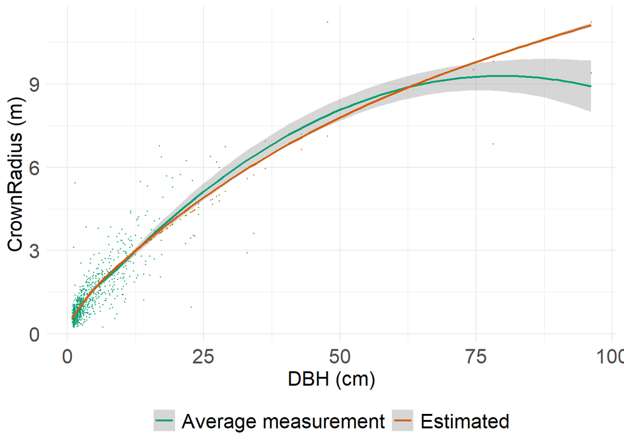

```r
FTH %>%
  ggplot() +
  aes(x = DBH, y = CrownRadius) +
  geom_point(size = 0.2, aes(color = "Average measurement")) +
  geom_smooth(span = 0.75, linewidth = 0.8, aes(color = "Average measurement")) +
  geom_point(aes(y = CrownRadius_est, color = "Estimated"), size = 0.2) +
  geom_smooth(aes(y = CrownRadius_est, color = "Estimated"), span = 0.75, linewidth = 0.8) +

  theme_minimal() +
  scale_color_manual(values = c("Average measurement" = "#009E73",
                                "Estimated"= "#D55E00")) +
  labs(x ="DBH (cm)", y = "CrownRadius (m)") +
  theme(axis.title= element_text(size=16), axis.text= element_text(size=16),
        legend.title= element_blank(), legend.text= element_text(size=16),
        legend.position="bottom")
```

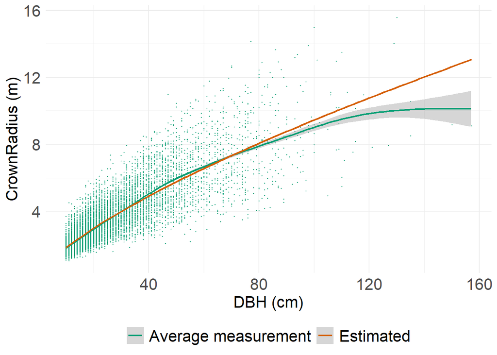

```r
CC %>%
  ggplot() +
  aes(x = DBH, y = CrownRadius) +
  geom_point(size = 0.2, aes(color = "Average measurement")) +
  geom_smooth(span = 0.75, linewidth = 0.8, aes(color = "Average measurement")) +
  geom_point(aes(y = CrownRadius_est, color = "Estimated"), size = 0.2) +
  geom_smooth(aes(y = CrownRadius_est, color = "Estimated"), span = 0.75, linewidth = 0.8) +

  theme_minimal() +
  scale_color_manual(values = c("Average measurement" = "#009E73",
                                "Estimated"= "#D55E00")) +
  labs(x ="DBH (cm)", y = "CrownRadius (m)") +
  theme(axis.title= element_text(size=16), axis.text= element_text(size=16),
        legend.title= element_blank(), legend.text= element_text(size=16),
        legend.position="bottom")
```